← Materiały bloku: Kwantowe wyżarzanie kombinatorycznych problemów optymalizacyjnych · podgląd notatnika `wprowadzenie_do_teorii_grafow.ipynb` · pobierz plik .ipynb

# Łagodne wprowadzenie do teorii grafów

Teoria grafów bada struktury złożone z **wierzchołków** i **krawędzi**. Można jej używać do opisywania wielu sytuacji z życia codziennego, na przykład:

- sieci dróg między miastami,
- połączeń między komputerami,
- relacji znajomości między osobami.

W tym notatniku poznamy kilka podstawowych pojęć.

## 1. Graf nieskierowany

**Graf nieskierowany** to para złożona z:

- zbioru **wierzchołków**,
- zbioru **krawędzi** łączących niektóre pary wierzchołków.

W grafie nieskierowanym połączenie nie ma kierunku. Jeżeli wierzchołek $A$ jest połączony z $B$, to jednocześnie $B$ jest połączony z $A$.

Możemy to zapisać symbolicznie jako:

$$G = (V, E)$$

gdzie:

- $V$ oznacza zbiór wierzchołków,
- $E$ oznacza zbiór krawędzi.

## 2. Wierzchołki i krawędzie

### Wierzchołki

**Wierzchołki** to podstawowe obiekty grafu. Można o nich myśleć jak o punktach.

Przykład: w sieci kolejowej wierzchołkami mogą być miasta.

### Krawędzie

**Krawędzie** to połączenia między wierzchołkami.

Przykład: jeśli dwa miasta są połączone linią kolejową, to między odpowiadającymi im wierzchołkami rysujemy krawędź.

Jeśli mamy wierzchołki $A$, $B$, $C$ oraz krawędzie $AB$ i $BC$, to oznacza to, że:

- $A$ jest połączony z $B$,
- $B$ jest połączony z $C$,
- ale $A$ nie jest połączony z $C$.

## 3. Przykład prostego grafu nieskierowanego

Rozważmy graf o wierzchołkach:

$$V = \{A, B, C, D\}$$

oraz krawędziach:

$$E = \{\{A,B\}, \{A,C\}, \{C,D\}, \{A,D\}\}$$

To znaczy, że:

- $A$ łączy się z $B$,
- $A$ łączy się z $C$,
- $C$ łączy się z $D$.

Nie ma tu na przykład krawędzi między $B$ i $D$.

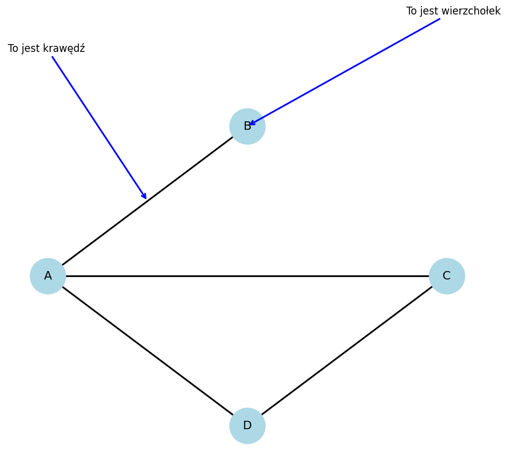

```python
import matplotlib.pyplot as plt
import networkx as nx

# Mały graf nieskierowany
G = nx.Graph()
G.add_edges_from([
    ("A", "B"),
    ("A", "C"),
    ("C", "D"),
    ("A", "D"),
])

pos = {
    "A": (0, 1),
    "B": (1, 1.8),
    "C": (2, 1),
    "D": (1, 0.2),
}

plt.figure(figsize=(8, 6))
nx.draw(
    G,
    pos,
    with_labels=True,
    node_size=1800,
    node_color="lightblue",
    font_size=14,
    width=2,
)

# Strzałka i podpis do wierzchołka
plt.annotate(
    "To jest wierzchołek",
    xy=pos["B"],
    xytext=(1.8, 2.4),
    arrowprops=dict(arrowstyle="->", lw=2, color="blue"),
    fontsize=12,
)

# Strzałka i podpis do krawędzi
x1, y1 = pos["A"]
x2, y2 = pos["B"]
srodek_krawedzi = ((x1 + x2) / 2, (y1 + y2) / 2)
plt.annotate(
    "To jest krawędź",
    xy=srodek_krawedzi,
    xytext=(-0.2, 2.2),
    arrowprops=dict(arrowstyle="->", lw=2, color="blue"),
    fontsize=12,
)


plt.axis("off")
plt.tight_layout()
plt.show()
```

## 4. Graf pełny

**Graf pełny** to taki graf, w którym każda para różnych wierzchołków jest połączona krawędzią.

Innymi słowy: każdy wierzchołek jest połączony z każdym innym.

Graf pełny o $n$ wierzchołkach oznaczamy zwykle przez:

$$K_n$$

### Przykład

Graf pełny $K_4$ ma 4 wierzchołki i wszystkie możliwe połączenia między nimi.

Liczba krawędzi w grafie pełnym $K_n$ wynosi:

$$\frac{n(n-1)}{2}$$

Na przykład dla $n = 4$ otrzymujemy:

$$\frac{4\cdot 3}{2} = 6$$

czyli graf $K_4$ ma 6 krawędzi.

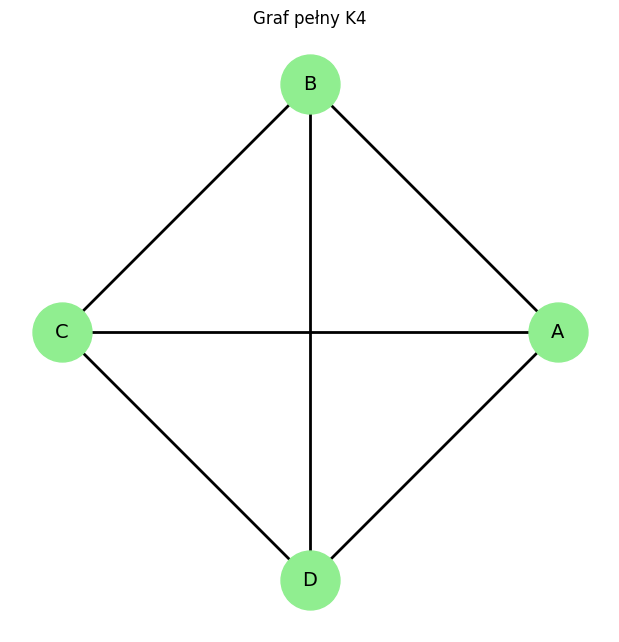

```python
import matplotlib.pyplot as plt
import networkx as nx

# Graf pełny K4: każdy wierzchołek jest połączony z każdym innym
n = 4
G = nx.complete_graph(n)
labels = {i: chr(65 + i) for i in range(n)}
pos = nx.circular_layout(G)

plt.figure(figsize=(6, 6))
nx.draw(
    G,
    pos,
    labels=labels,
    with_labels=True,
    node_size=1800,
    node_color="lightgreen",
    font_size=14,
    width=2,
)

plt.title("Graf pełny K4")
plt.axis("off")
plt.tight_layout()
plt.show()
```

## 5. Graf dwudzielny

**Graf dwudzielny** to taki graf, którego zbiór wierzchołków można podzielić na dwa rozłączne zbiory, na przykład $U$ i $W$, tak aby:

- każda krawędź łączyła wierzchołek z $U$ z wierzchołkiem z $W$,
- nie było krawędzi między dwoma wierzchołkami należącymi do tego samego zbioru.

Można to sobie wyobrazić jako dwa „rzędy” punktów, gdzie połączenia idą tylko między rzędami.

### Przykład

Niech:

$$U = \{u_1, u_2, u_3\}, \qquad W = \{w_1, w_2, w_3, w_4\}$$

Jeśli krawędzie łączą niektóre $u_i$ z niektórymi $w_j$, to taki graf może być grafem dwudzielnym.

Przykładowe zastosowanie:

- jeden zbiór oznacza uczniów,
- drugi zbiór oznacza koła zainteresowań,
- krawędź oznacza, że dany uczeń należy do danego koła.

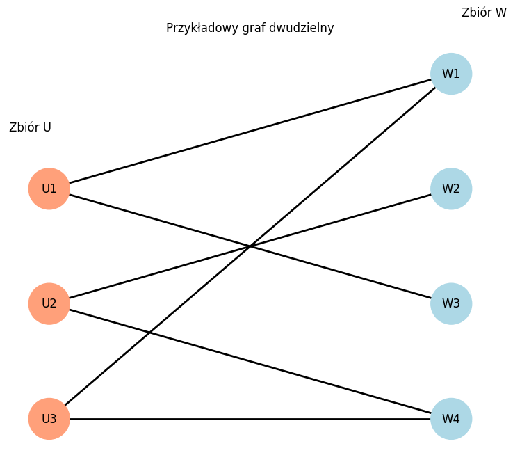

```python
import matplotlib.pyplot as plt
import networkx as nx

# Graf dwudzielny: wierzchołki dzielą się na dwa zbiory
lewa_czesc = ["U1", "U2", "U3"]
prawa_czesc = ["W1", "W2", "W3", "W4"]

G = nx.Graph()
G.add_nodes_from(lewa_czesc, bipartite=0)
G.add_nodes_from(prawa_czesc, bipartite=1)
G.add_edges_from([
    ("U1", "W1"),
    ("U1", "W3"),
    ("U2", "W2"),
    ("U2", "W4"),
    ("U3", "W1"),
    ("U3", "W4"),
])

pos = {}
for i, node in enumerate(lewa_czesc):
    pos[node] = (0, len(lewa_czesc) - i)
for i, node in enumerate(prawa_czesc):
    pos[node] = (2, len(prawa_czesc) - i)

colors = ["lightsalmon" if node in lewa_czesc else "lightblue" for node in G.nodes()]

plt.figure(figsize=(7, 6))
nx.draw(
    G,
    pos,
    with_labels=True,
    node_size=1800,
    node_color=colors,
    font_size=12,
    width=2,
)

plt.text(-0.2, 3.5, "Zbiór U", fontsize=12)
plt.text(2.05, 4.5, "Zbiór W", fontsize=12)
plt.title("Przykładowy graf dwudzielny")
plt.axis("off")
plt.tight_layout()
plt.show()
```

## 6. Graf pełny dwudzielny

Szczególnym przypadkiem grafu dwudzielnego jest **graf pełny dwudzielny**.

Oznaczamy go przez:

$$K_{m,n}$$

Oznacza to, że:

- pierwszy zbiór ma $m$ wierzchołków,
- drugi zbiór ma $n$ wierzchołków,
- każdy wierzchołek z pierwszego zbioru jest połączony z każdym wierzchołkiem z drugiego zbioru.

Na przykład $K_{3,4}$ ma:

- 3 wierzchołki w pierwszej części,
- 4 wierzchołki w drugiej części,
- razem $3 \cdot 4 = 12$ krawędzi.

## 7. Cykl Eulera i cykl Hamiltona

**Cykl Eulera** to taka droga w grafie, która przechodzi przez **każdą krawędź dokładnie jeden raz** i wraca do punktu startowego. Najważniejsze jest tu więc odwiedzanie **krawędzi**.

Przykład: wyobraź sobie rysunek, który da się narysować jednym pociągnięciem ołówka i wrócić do miejsca startu, nie rysując żadnej linii drugi raz.

**Cykl Hamiltona** to cykl, który odwiedza **każdy wierzchołek dokładnie jeden raz** i wraca do wierzchołka początkowego. Tutaj najważniejsze są więc **wierzchołki**, a nie krawędzie.

Czyli w skrócie:

- **cykl Eulera** — każda **krawędź** raz,
- **cykl Hamiltona** — każdy **wierzchołek** raz.

To ważna różnica: w cyklu Eulera patrzymy na przejście po liniach grafu, a w cyklu Hamiltona na odwiedzenie wszystkich punktów grafu.

## 8. Podsumowanie

Najważniejsze pojęcia:

- **graf nieskierowany** - graf, w którym krawędzie nie mają kierunku,
- **wierzchołki** - punkty grafu,
- **krawędzie** - połączenia między wierzchołkami,
- **graf pełny** - graf, w którym każda para różnych wierzchołków jest połączona,
- **graf dwudzielny** - graf, którego wierzchołki można podzielić na dwa zbiory, a krawędzie biegną tylko między tymi zbiorami.
- **cykl Eulera** - droga w grafie, która przechodzi przez **każdą krawędź dokładnie jeden raz** i wraca do punktu startowego.
- **cykl Hamiltona** - groga w grafie, która odwiedza **każdy wierzchołek dokładnie jeden raz** i wraca do wierzchołka początkowego.

# Literatura

- Diestel, R. (2000). [Graph Theory](https://www.prip.tuwien.ac.at/staffpages/yll/docs/graph_theory_book_diestel.pdf)
- Wilson, R. J. (2007). Wprowadzenie do teorii grafów.